# scNMT_NOMeWorkFlow Help

Aaron Doe

11/20/2019

## Help Page

### Setting up Snakemake

The first step to setting up this pipeline is to link your samples. To do this, make a samples directory in your working directory. Then, in that samples directory create a directory called “raw”. You can then symlink your raw fastqs file into this directory.

```bash
ln -s /path/to/fastqs/* samples/raw/
```

This will create a symlink for each FASTQ file located in the samples/raw directory. Make sure your symlinks follow the naming conventions in the Snakefile:

"samples/raw/{sample}_R1.fastq.gz"

**IMPORTANT**

There is a gene metadata file in the data directory. This is an example metadata.txt file. **YOU MUST CREATE A NEW METADATA FILE WITH YOUR SAMPLE INFORMATION**

You should then run a snakemake dry run to ensure there are no errors and that all of your samples will be processed.

```bash
snakemake -np --verbose
```

### Bismart Rule Outputs

#### Trimming

The first rule is trimming which outputs trimmed samples, a trimming report which summarizes how the trimming went, as well as an html outputted from FastQC.

For more information on FastQC and how to interpret its output go to, https://www.bioinformatics.babraham.ac.uk/projects/fastqc/

#### Mapping_R1/Mapping_R2

Although these cells are paired-end sequenced, we map them as two individual single end reads. This is due to poor mapping efficiency when they are mapped as paired end reads. We use Bismark to map these reads which runs bowtie2 under the hood. It outputs a BAM file for each read as well as a mapping report for each read. This mapping report shows the mapping efficiency, which we hope to be above 30%, as well as the percentage of methylated C’s in different contexts. Ideally the majority of methylated C’s are in CpG context. If the percentage of methylated C’s in CHG or CHH context is above 20%, then there may be issues.

#### Deduplicate

This step is to get rid of PCR duplicates in the BAM file, so we don’t overcount certain reads.

#### Methylation Extractor

The first step of this rule is to merge the R1 and R2 bam files into one. Then, it takes the merged bam file and runs it through Bismark’s methylation extractor. This step extracts the methylation information for every cytosine in the read. It creates a different file for each type of cytosine methylation site for each cell. These files contain the read label for the corresponding read, whether or not it is methylated, and its location on the chromosome. It also outputs a bedGraph for every cell containing the location of each site and whether or not it is methylated. It also outputs a coverage file which looks at each site and tells the methylation percentage, number of times the site is methylated, and number of times the site is unmethylated. It also outputs an M-bias file which outputs the position, count methylated, count unmethylated, percent methylation, and coverage values for each site. Finally, it ouputs a splitting report that gives an overall report of the process.

#### Coverage2cytosine

This step takes the coverage report from the last step and splits it into the methylation and chromatin accessibility information we are interested in. It outputs a coverage file and a report for CpG and GpC individually. The coverage file contains the location of each site, the percentage of times it is methylated/accessible, the number of methylated/accessible sites, and the number of unmethylated/non-accessible sites. The report is similar in that it shows the location and number of sites methylated/accessible vs. unmethylated/non-accessible. The extra piece it has is that it lists the specific context of each site as well.

#### C2C Coverage Filter

This step takes the CpG and GpC coverage files from the previous step and filters them. It removes sites that were not covered by any read.

#### Binarize

This step takes the filtered coverage file and binarizes the rates. It removes sites which are methylated in 50% of the reads and then rounds the rest either down to zero or up to 100% resulting in either a 0 or a 1. This is done because a site is either methylated or unmethylated, any site that is methylated in only a percentage of reads is due to a read error.

#### Create Reports

This is the final step in the alignment process and takes all of the cell coverage reports we have created and merges them into one report file. This report has the cells as rows (2 rows for each cell, one for R1 and one for R1) and then a number of statistics as columns. The columns are total number of reads, total number of mapped reads, percentage of mapped reads, total C’s, percentage of CpG’s, percentage of CHG’s, and percentage of CHH’s. This report is useful to look at to check the range of depths that your cells were sequenced to as well as the breakdown of the methylation sites. Having a percentage of CHG and CHH above 20% for a cell is a red flag, so this is a good place to look and see if any of your cells fall into this category.

### QC

#### Counts Stats

This step takes the report created in the previous step as input and runs a number of QC processes on it. It outputs two tables and a number of plots. The two tables it outputs are a sample stats table and a sample read report table. The sample stats table contains, for each cell, the context, the coverage of that context, and the mean methylation/accessibility of that context for that cell. The read report contains the cell, the total number of reads for that cell, the total number of mapped reads for that cell, and the percentage of mapped reads. The first set of plots are a series of coverage plots. These plots tell you the read coverage of the different contexts. There are also a number of plots that show mean rates. This tells us the mean amount of methylation and accessibility of these cells. These are important because the whole analysis is based on these methylated/accessible sites, so if we have a low rate of them the analysis will suffer.

#### Methylation Accessibility QC

This step takes the same original report as input and does similar things to the previous rule. However, this time we will use the plots to filter out cells that perform poorly. It outputs the same plots as before, but this time includes cutoff lines (that can be adjusted) that show which cells are not passing QC and why. It then outputs a new sample stats and sample read report table that includes whether or not the cell passed QC.

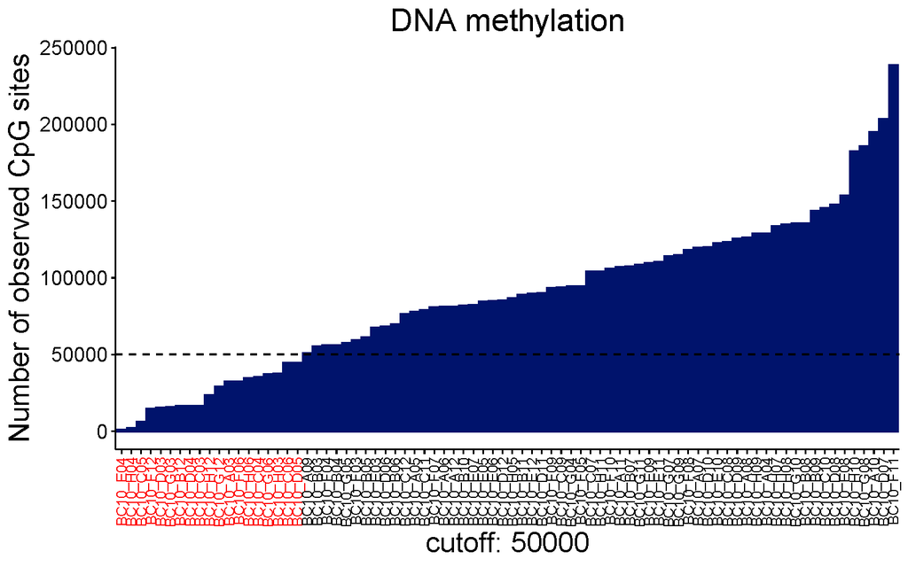

Example QC Plot

### Profiles

#### Get Genes

The first step for building these profiles is to get the bed files for the genome annotations of interest. In this step you can specify the size of the window you are looking at around your annotation of choice. It also builds a gene metadata table containing The gene position and chromosome information based on the given GTF file.

#### Accessibility/Methylation Profiles

This step takes the QC sample stats table, gene metadata file, and binarized methylation/accessibility files as input and produces profile plots around the annotation of choice. It looks at the methylation/accessibility across all promoters (if that is your annotation of choice) for each cell and then averages those values and produces one plot with a line for each cell and the promoter in the middle of the x axis stretching out in both directions for the length of the window. It also produces a second plot which averages over the cells to create one line with a spread to show the methylation/accessibility rates across all promoters.

#### Annotate Accessibility/Methylation

This step takes in the same input as a previous step, but has different ouputs. In this case it outputs a series of annotation files, for a variety of genome annotations, that contain the acessibility/methylation information for the given annotation.

#### Plot Annotation

This step takes all of the annotation files that were just created as input and outputs a summary of the variance and the means for each annotation. This summary is in the form of a series of boxplots. There are four boxplots in total, one for the accessibility mean rate, one for the methylation mean rate, one for the accessibility variance, and one for the methylation variance.

#### Accessibility and Methylation Correlation

This takes all of the annotation files as input and runs correlations between the accessibility and methylation. It runs weighted pearson correlations for each site across all of the annotated sites. It also identifies which correlations are significant by their placement on the y axis.